# Data_visualization_principles_20191007_717_oh

## 7.9 Encoding a third variable

An earlier scatterplot showed the relationship between infant survival and average income. Below is a version of this plot that encodes three variables: OPEC membership, region, and population.

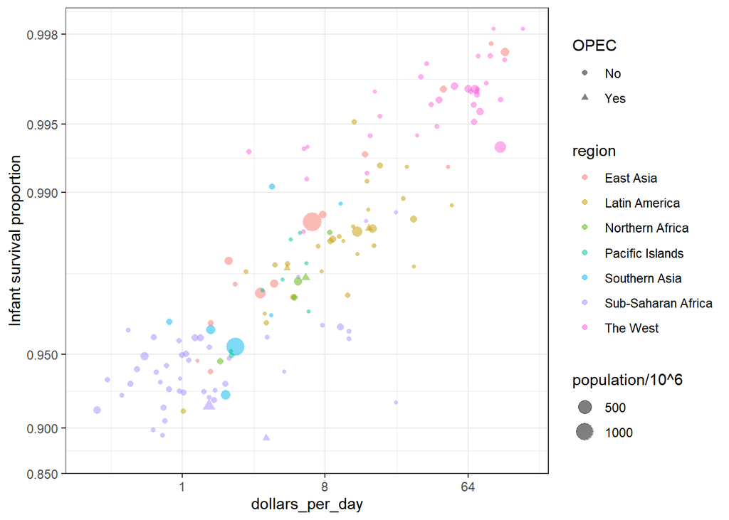

We encode categorical variables with color and shape. These shapes can be controlled with `shape` argument. Below are the shapes available for use in R. For the last five, the color goes inside.

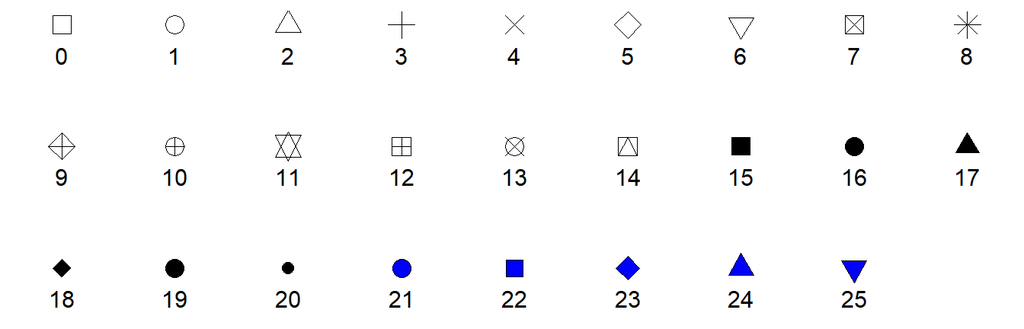

For continuous variables, we can use color, intensity, or size. We now show an example of how we do this with a case study.

When selecting colors to quantify a numeric variable, we choose between two options: sequential and diverging. Sequential colors are suited for data that goes from high to low. High values are clearly distinguished from low values. Here are some examples offered by the package `RColorBrewer`:

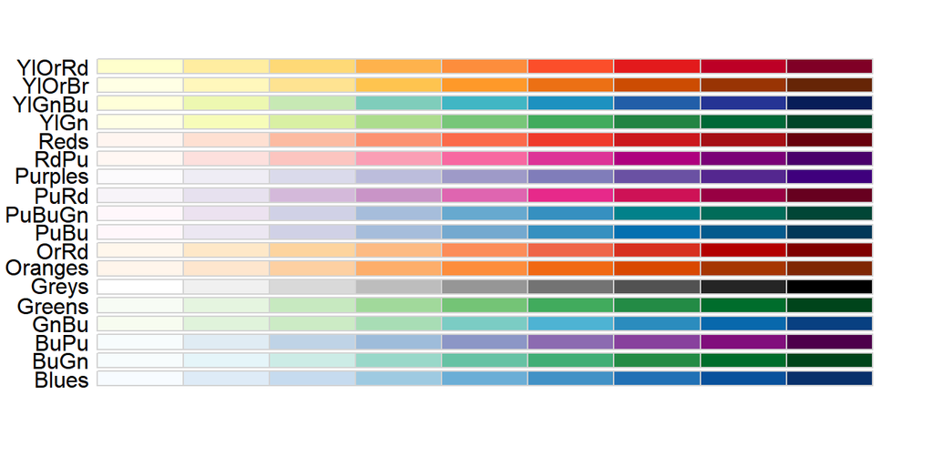

Diverging colors are used to represent values that diverge from a center. We put equal emphasis on both ends of the data range: higher than the center and lower than the center. An example of when we would use a divergent pattern would be if we were to show height in standard deviations away from the average. Here are some examples of divergent patterns:

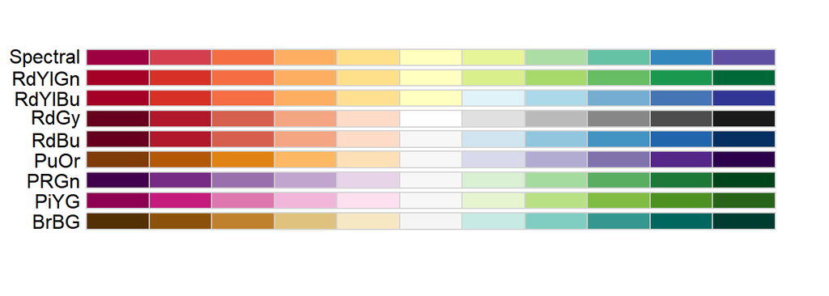

## 7.10 Avoid pseudo-three-dimensional plots

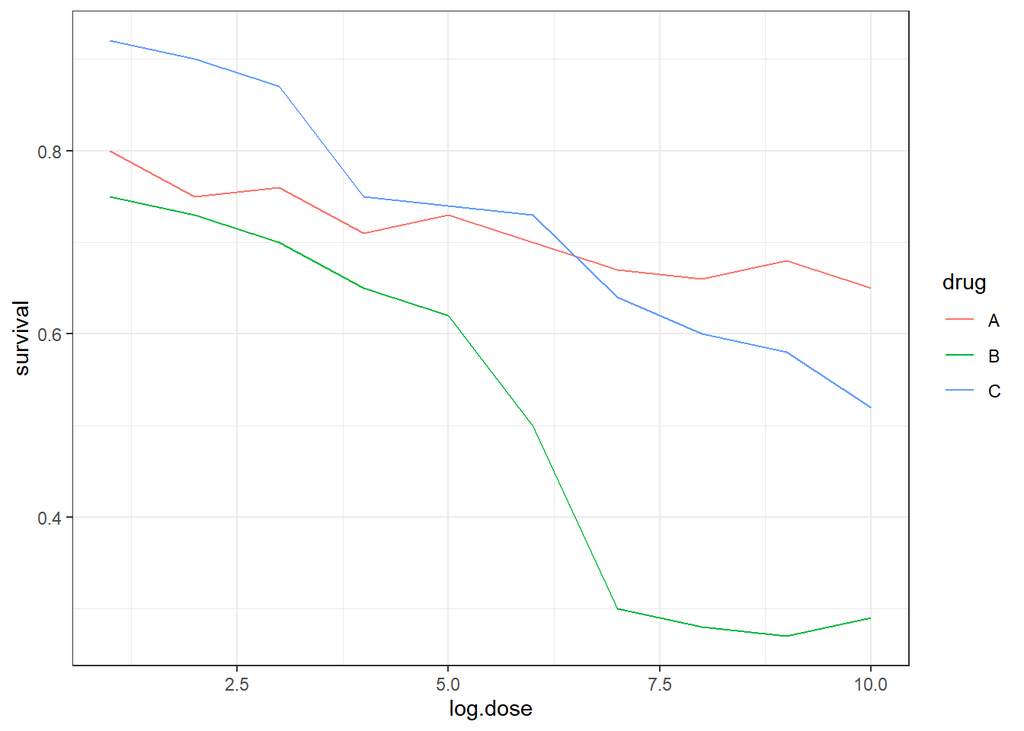

## 7.11 Avoid too many significant digits

By default, statistical software like R returns many significant digits. The default behavior in R is to show 7 significant digits. That many digits often adds no information and the added visual clutter can make it hard for the viewer to understand the message. As an example, here are the per 10,000 disease rates, computed from totals and population in R, for California across the five decades:

| state | year | Measles | Pertussis | Polio |
| --- | --- | --- | --- | --- |
| California | 1940 | 37.8826320 | 18.3397861 | 18.3397861 |
| California | 1950 | 13.9124205 | 4.7467350 | 4.7467350 |
| California | 1960 | 14.1386471 | 0.0000000 | 0.0000000 |
| California | 1970 | 0.9767889 | 0.0000000 | 0.0000000 |
| California | 1980 | 0.3743467 | 0.0515466 | 0.0515466 |

We are reporting precision up to 0.00001 cases per 10,000, a very small value in the context of the changes that are occurring across the dates. In this case, two significant figures is more than enough and clearly makes the point that rates are decreasing:

| state | year | Measles | Pertussis | Polio |
| --- | --- | --- | --- | --- |
| California | 1940 | 37.9 | 18.3 | 18.3 |
| California | 1950 | 13.9 | 4.7 | 4.7 |
| California | 1960 | 14.1 | 0.0 | 0.0 |
| California | 1970 | 1.0 | 0.0 | 0.0 |
| California | 1980 | 0.4 | 0.1 | 0.1 |

Useful ways to change the number of significant digits or to round numbers are `signif` and `round`. You can define the number of significant digits globally by setting options like this: `options(digits = 3)`.

Another principle related to displaying tables is to place values being compared on columns rather than rows. Note that our table above is easier to read than this one:

| state | disease | 1940 | 1950 | 1960 | 1970 | 1980 |
| --- | --- | --- | --- | --- | --- | --- |
| California | Measles | 37.9 | 13.9 | 14.1 | 1 | 0.4 |
| California | Pertussis | 18.3 | 4.7 | 0.0 | 0 | 0.1 |
| California | Polio | 18.3 | 4.7 | 0.0 | 0 | 0.1 |

## 7.12 Know your audience

Graphs can be used for 1) our own exploratory data analysis, 2) to convey a message to experts, or 3) to help tell a story to a general audience. Make sure that the intended audience understands each element of the plot.

As a simple example, consider that for your own exploration it may be more useful to log-transform data and then plot it. However, for a general audience that is unfamiliar with converting logged values back to the original measurements, using a log-scale for the axis instead of log-transformed values will be much easier to digest.

## Exercises

For these exercises, we will be using the vaccines data in the **dslabs** package:

1. Pie charts are appropriate:

1. When we want to display percentages.
2. When **ggplot2** is not available.
3. When I am in a bakery.  
   **d. Never. Barplots and tables are always better.**

2. What is the problem with the plot below:

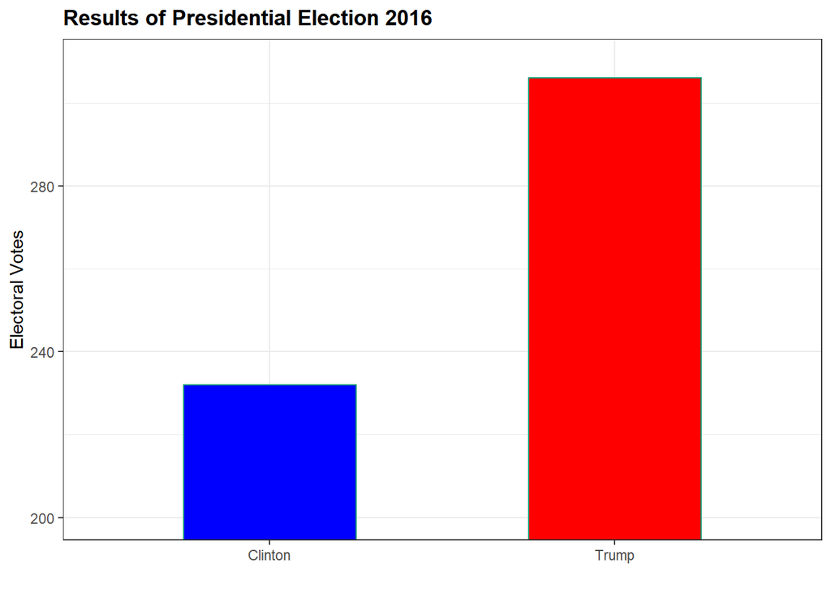

1. The values are wrong. The final vote was 306 to 232.  
   **b. The axis does not start at 0. Judging by the length, it appears Trump received 3 times as many votes when, in fact, it was about 30% more.**
2. The colors should be the same.
3. Percentages should be shown as a pie chart.

3. Take a look at the following two plots. They show the same information: 1928 rates of measles across the 50 states.

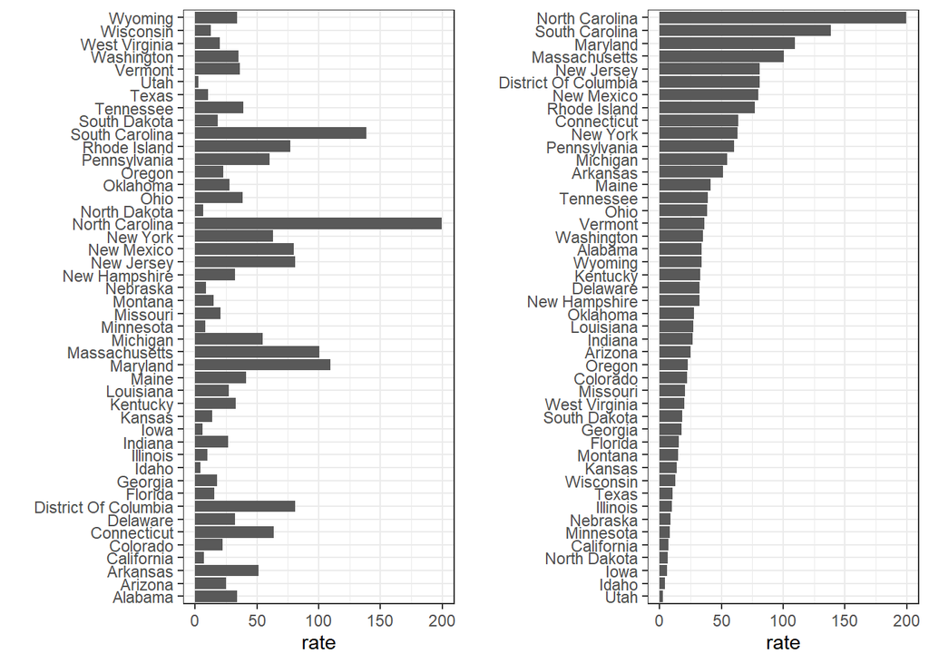

Which plot is easier to read if you are interested in determining which are the best and worst states in terms of rates, and why?

1. They provide the same information, so they are both equally as good.
2. The plot on the right is better because it orders the states alphabetically.  
   **c. The plot on the right is better because alphabetical order has nothing to do with the disease and by ordering according to actual rate, we quickly see the states with most and least rates.**
3. Both plots should be a pie chart.

Note what happens when we make a barplot:

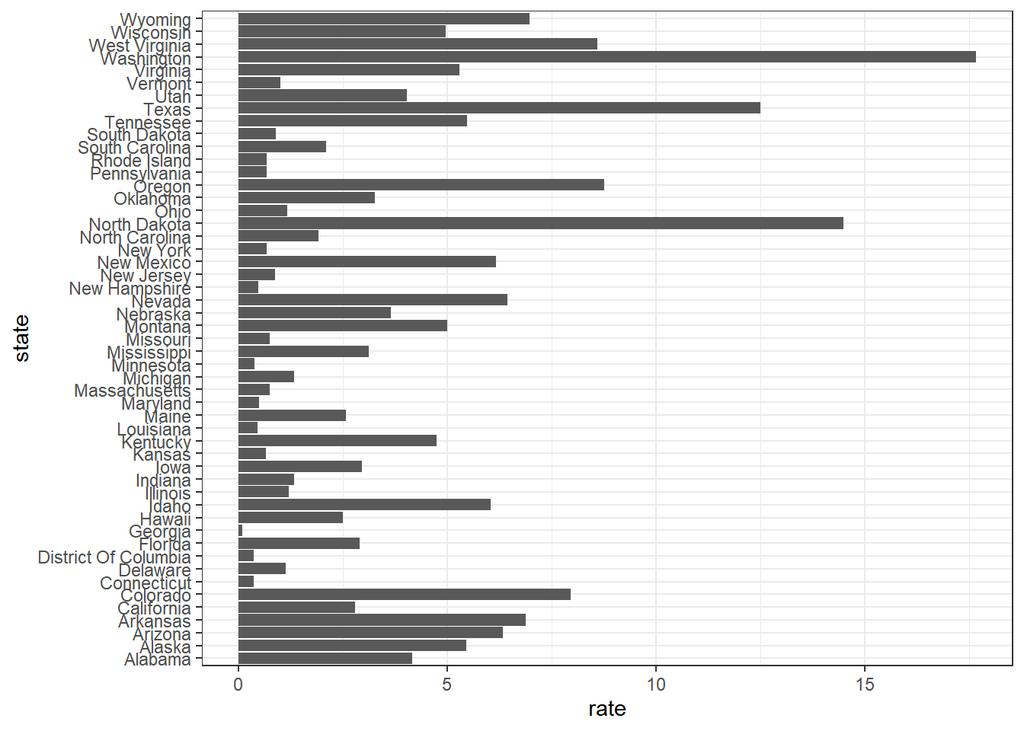

Redefine the `state` object so that the levels are re-ordered. Print the new object `state` and its levels so you can see that the vector is not re-ordered by the levels.

```
 [1] Alabama              Alaska               Arizona
 [4] Arkansas             California           Colorado
 [7] Connecticut          Delaware             District Of Columbia
[10] Florida              Georgia              Hawaii
[13] Idaho                Illinois             Indiana
[16] Iowa                 Kansas               Kentucky
[19] Louisiana            Maine                Maryland
[22] Massachusetts        Michigan             Minnesota
[25] Mississippi          Missouri             Montana
[28] Nebraska             Nevada               New Hampshire
[31] New Jersey           New Mexico           New York
[34] North Carolina       North Dakota         Ohio
[37] Oklahoma             Oregon               Pennsylvania
[40] Rhode Island         South Carolina       South Dakota
[43] Tennessee            Texas                Utah
[46] Vermont              Virginia             Washington
[49] West Virginia        Wisconsin            Wyoming
attr(,"scores")
             Georgia District Of Columbia          Connecticut
          0.09987991           0.35873614           0.36986840
           Minnesota            Louisiana        New Hampshire
          0.37722410           0.46088071           0.47181511
            Maryland               Kansas             New York
          0.49922233           0.66386422           0.66849058
        Pennsylvania         Rhode Island        Massachusetts
          0.67687303           0.68207448           0.74762338
            Missouri           New Jersey         South Dakota
          0.75696354           0.88414264           0.90289534
             Vermont             Delaware                 Ohio
          1.00970314           1.13098183           1.16382241
            Illinois             Michigan              Indiana
          1.20115480           1.33466700           1.34027323
      North Carolina       South Carolina               Hawaii
          1.92529764           2.10412531           2.50173748
               Maine           California              Florida
          2.57520433           2.79313560           2.89358806
                Iowa          Mississippi             Oklahoma
          2.94948911           3.11366532           3.27496900
            Nebraska                 Utah              Alabama
          3.64389801           4.03005836           4.16107582
            Kentucky            Wisconsin              Montana
          4.74576011           4.96246019           5.00433320
            Virginia               Alaska            Tennessee
          5.28270939           5.46389893           5.47344506
               Idaho           New Mexico              Arizona
          6.03115170           6.15969926           6.32695891
              Nevada             Arkansas              Wyoming
          6.43683882           6.87899954           6.97303449
            Colorado        West Virginia               Oregon
          7.96331905           8.59456463           8.75036439
               Texas         North Dakota           Washington
         12.49773953          14.48024642          17.65180349
51 Levels: Georgia District Of Columbia Connecticut ... Washington
```

5. Now with one line of code, define the `dat` table as done above, but change the use mutate to create a rate variable and re-order the state variable so that the levels are re-ordered by this variable. Then make a barplot using the code above, but for this new `dat`.

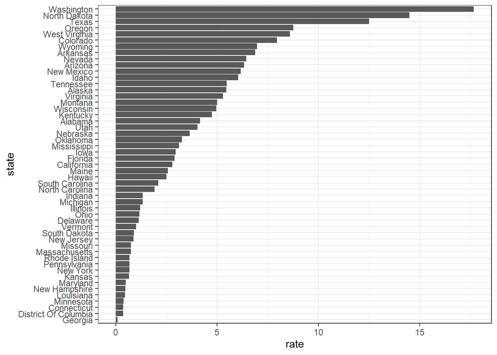

6. Say we are interested in comparing gun homicide rates across regions of the US. We see this plot:

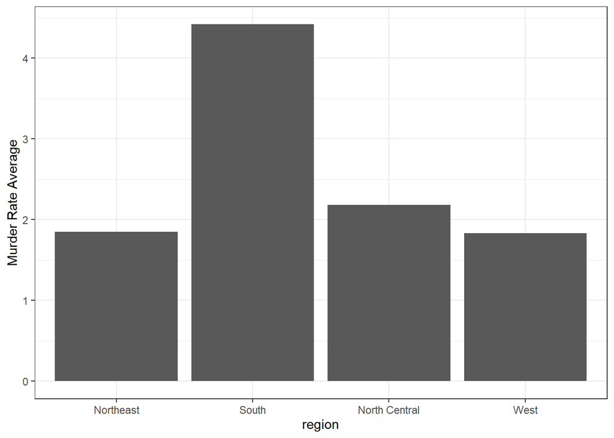

and decide to move to a state in the western region. What is the main problem with this interpretation?

1. The categories are ordered alphabetically.
2. The graph does not show standarad errors.  
   **c. It does not show all the data. We do not see the variability within a region and it’s possible that the safest states are not in the West.**
3. The Northeast has the lowest average.

8. The plots below show three continuous variables.

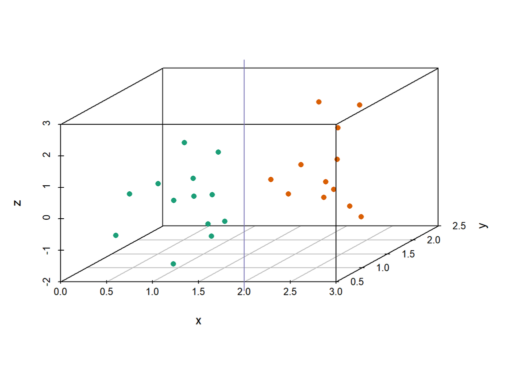

The line $x=2$ appears to separate the points. But it is actually not the case, which we can see by plotting the data in a couple of two-dimensional points.

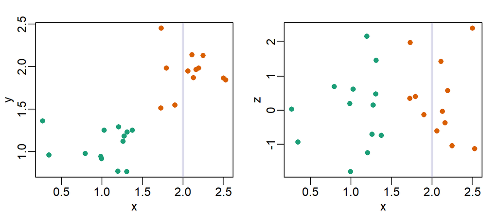

Why is this happening?

9. Reproduce the image plot we previously made but for smallpox. For this plot, do not include years in which cases were not reported in 10 or more weeks.

10. Now reproduce the time series plot we previously made, but this time following the instructions of the previous question.

11. For the state of California, make time series plots showing rates for all diseases. Include only years with 10 or more weeks reporting. Use a different color for each disease.

12. Now do the same for the rates for the US. Hint: compute the US rate by using summarize, the total divided by total population.

## 7.13 Case study: impact of vaccines on battling infectious diseases

```
'data.frame':   18870 obs. of  6 variables:
 $ disease        : Factor w/ 7 levels "Hepatitis A",..: 1 1 1 1 1 1 1 1 1 1 ...
 $ state          : Factor w/ 51 levels "Alabama","Alaska",..: 1 1 1 1 1 1 1 1 1 1 ...
 $ year           : num  1966 1967 1968 1969 1970 ...
 $ weeks_reporting: int  50 49 52 49 51 51 45 45 45 46 ...
 $ count          : num  321 291 314 380 413 378 342 467 244 286 ...
 $ population     : num  3345787 3364130 3386068 3412450 3444165 ...
```

We can now easily plot disease rates per year. Here are the measles data from California:

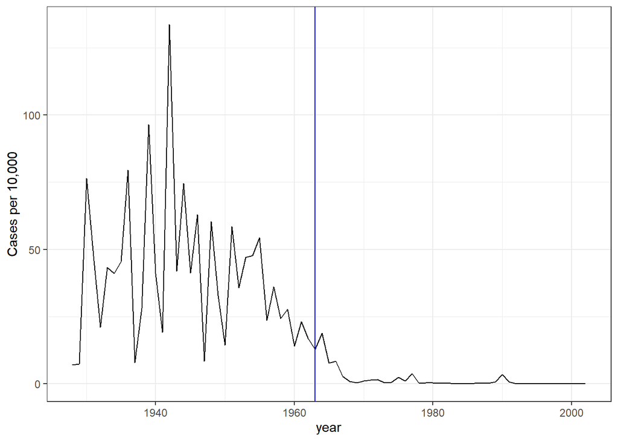

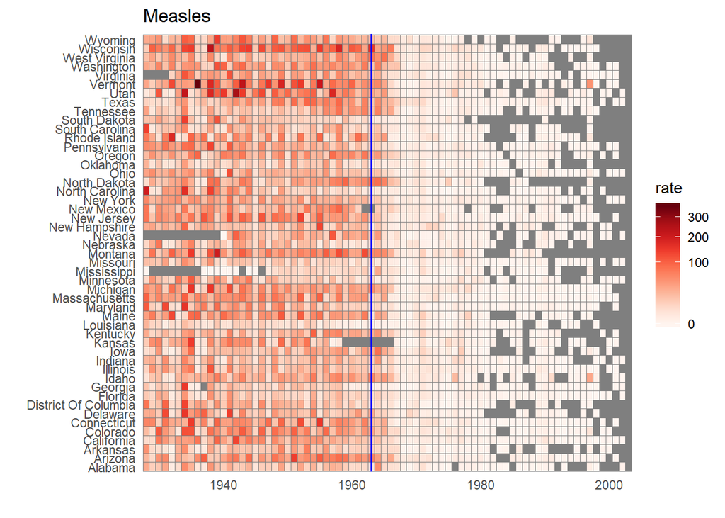

Now to make the plot we simply use the geom_line geometry:

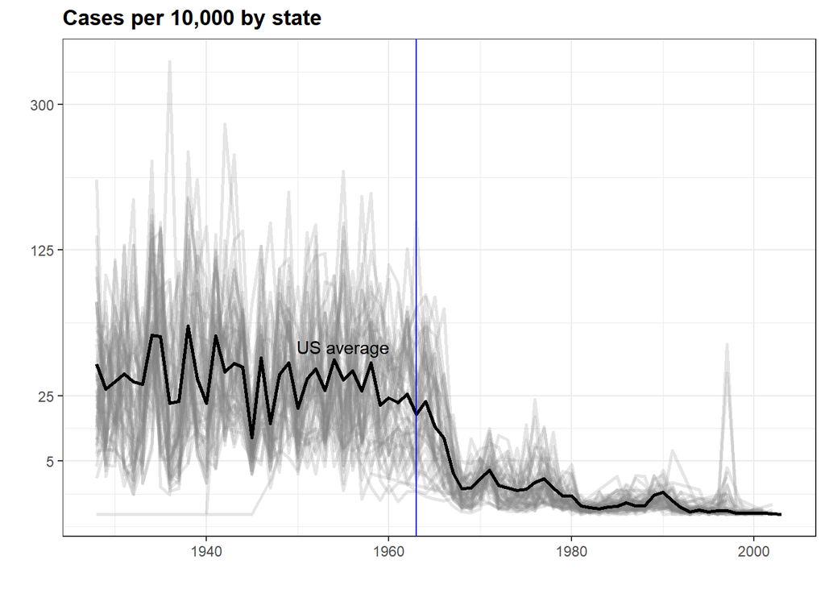

In theory, we could use color to represent the categorical value state, but it is hard to pick 50 distinct colors. ## Exercises

1. Reproduce the image plot we previously made but for smallpox. For this plot, do not include years in which cases were not reported in 10 or more weeks.

2. Now reproduce the time series plot we previously made, but this time following the instructions of the previous question for smallpox. 3. For the state of California, make a time series plot showing rates for all diseases. Include only years with 10 or more weeks reporting. Use a different color for each disease. 4. Now do the same for the rates for the US. Hint: compute the US rate by using summarize: the total divided by total population.

[^1]: http://kbroman.org/
[^2]: https://www.biostat.wisc.edu/~kbroman/presentations/graphs2017.pdf
[^3]: https://github.com/kbroman/Talk_Graphs
[^4]: http://paldhous.github.io/ucb/2016/dataviz/index.html
[^5]: http://mediamatters.org/blog/2013/04/05/fox-news-newest-dishonest-chart-immigration-enf/193507
[^6]: http://flowingdata.com/2012/08/06/fox-news-continues-charting-excellence/
[^7]: https://www.pakistantoday.com.pk/2018/05/18/whats-at-stake-in-venezuelan-presidential-vote
[^8]: https://www.youtube.com/watch?v=kl2g40GoRxg
[^9]: https://projecteuclid.org/download/pdf_1/euclid.ss/1177010488